# Tutorial aula 08: SIG

Andrea Sánchez-Tapia, Sara Mortara, Diogo S. B. Rocha

sex 19 jul 2019

# Manipulação de dados vetoriais

## Lendo dados vetoriais e selecionar subconjunto

Existem várias opções de pacotes para importar dados vetoriais. Aqui usaremos o `rgdal`. Verifique se já tem instalado com `library(rgdal)`, caso não carregue, então instale como de costume.

Importando um shape ([A Song of Ice and Fire Speculative World Map](http://www.sermountaingoat.co.uk/map/index.php), disponível em [Download](https://www.cartographersguild.com/attachment.php?attachmentid=73097&d=1430486966)) e plotando:

```r
westeros <- readOGR("./data/GoTRelease/political.shp", encoding = "UTF-8")
```

[figure not shown]

```r
plot(westeros, las = 1, axes = T)
abline(h = 0, lty = 2, col = "tomato") #plotando a linha do 'equador'
```

```r
names(westeros)
```

```
## [1] "id"        "name"      "ClaimedBy"
```

```r
westeros$ClaimedBy
```

```
##  [1] Night's Watch Tully         Wildlings     Night's Watch Stark
##  [6] Greyjoy       Martell       Baratheon     Arryn         Lannister
## [11] Targaryen     Tyrell
## 11 Levels: Arryn Baratheon Greyjoy Lannister Martell ... Wildlings
```

Selecionando ‘The North’ (região reivindicada pela casa Stark):

```r
stark <- westeros[westeros$ClaimedBy == "Stark",]
```

Plotando o mapa da área selecionada:

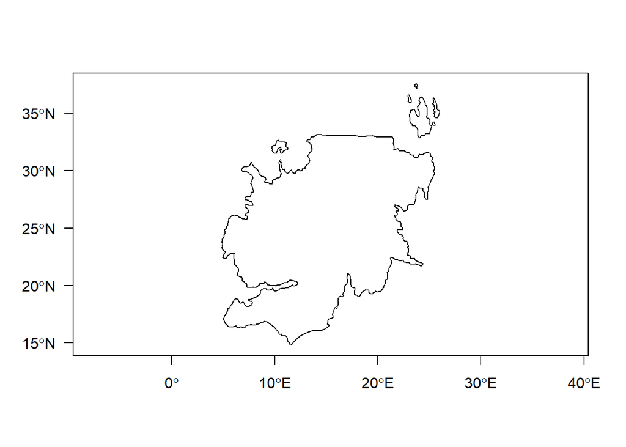

```r
plot(stark, axes = T, las = 1)
```

## Criando um buffer

Gerando pontos aleatórios:

```r
pontos <- spsample(stark, 10, 'random')
```

Plotando os pontos aleatórios:

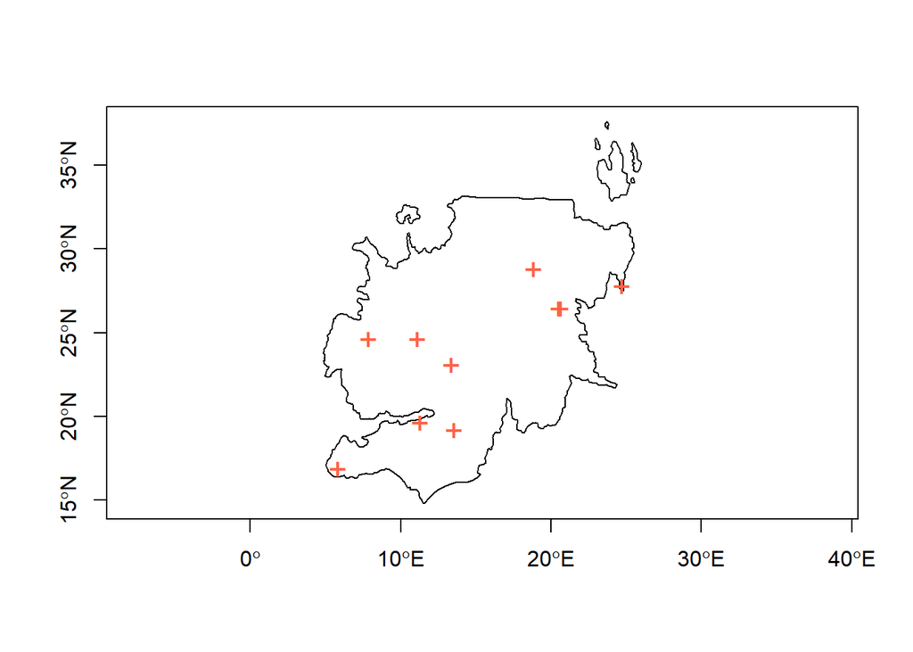

```r
plot(stark, axes = T)
points(pontos, pch = "+", col = "tomato", cex = 1.5)
```

Para criar o buffer vamos utilizar o pacote `raster`.

Criando o buffer e plotando:

```r
pontos.buffer <- buffer(pontos, width = 200000, dissolve = TRUE)
```

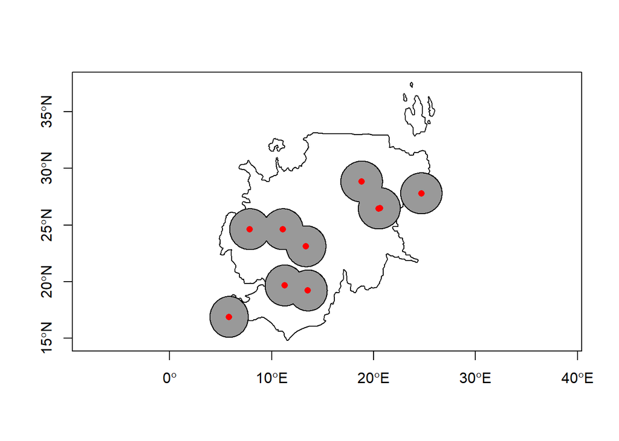

```r
plot(stark, axes = T)
plot(pontos.buffer, add = T, col = "grey60")
points(pontos, col = 'red', pch = 16)
```

Tente com o argumento `dissolve = FALSE` e veja a diferença.

Criar um buffer em vetores do tipo pontos, linhas e polígonos funcionam de forma similar. Deve-se ficar atento apenas ao argumento `width`. Veja um exemplo de buffer em um polígono.

Criando o buffer e plotando:

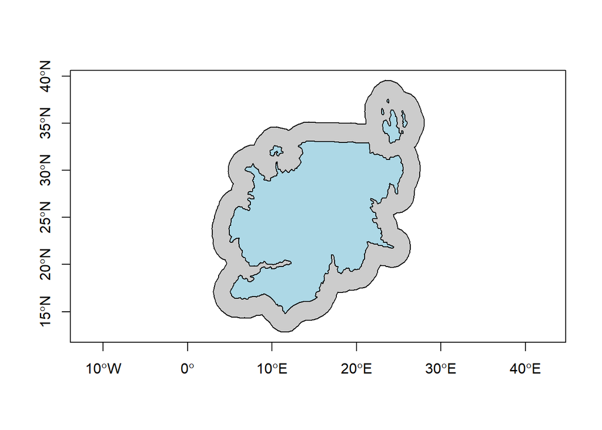

```r
stark.buffer <- buffer(stark, width = 2, dissolve = TRUE)
plot(stark.buffer, col = "grey80", axes = T)
plot(stark, add = T, col = "lightblue")
```

## Incluindo atributos em um objeto `Spatial`

Incluir novos atributos em um objeto `Spatial` é similar a incluir uma nova coluna em um data frame.

```r
westeros
```

```
## class       : SpatialPolygonsDataFrame
## features    : 12
## extent      : 0.9011003, 26.29015, -11.40838, 49.10222  (xmin, xmax, ymin, ymax)
## crs         : +proj=longlat +datum=WGS84 +no_defs +ellps=WGS84 +towgs84=0,0,0
## variables   : 3
## names       : id,            name, ClaimedBy
## min values  :  1,     Bran's Gift,     Arryn
## max values  :  9, The Westerlands, Wildlings
```

```r
westeros$regiao <- c(rep(1:3, each = 4))
westeros
```

```
## class       : SpatialPolygonsDataFrame
## features    : 12
## extent      : 0.9011003, 26.29015, -11.40838, 49.10222  (xmin, xmax, ymin, ymax)
## crs         : +proj=longlat +datum=WGS84 +no_defs +ellps=WGS84 +towgs84=0,0,0
## variables   : 4
## names       : id,            name, ClaimedBy, regiao
## min values  :  1,     Bran's Gift,     Arryn,      1
## max values  :  9, The Westerlands, Wildlings,      3
```

## Unindo polígonos

Unindo tudo:

[figure not shown]

```r
westeros_contorno = aggregate(westeros)
plot(westeros_contorno, axes = T)
```

Mas, também podemos unir os polígonos indexados:

Unindo por região:

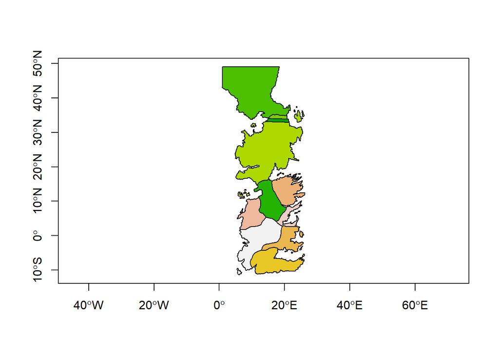

```r
new_westeros = aggregate(westeros, by = "regiao")
plot(westeros, axes = T, col = terrain.colors(12))
```

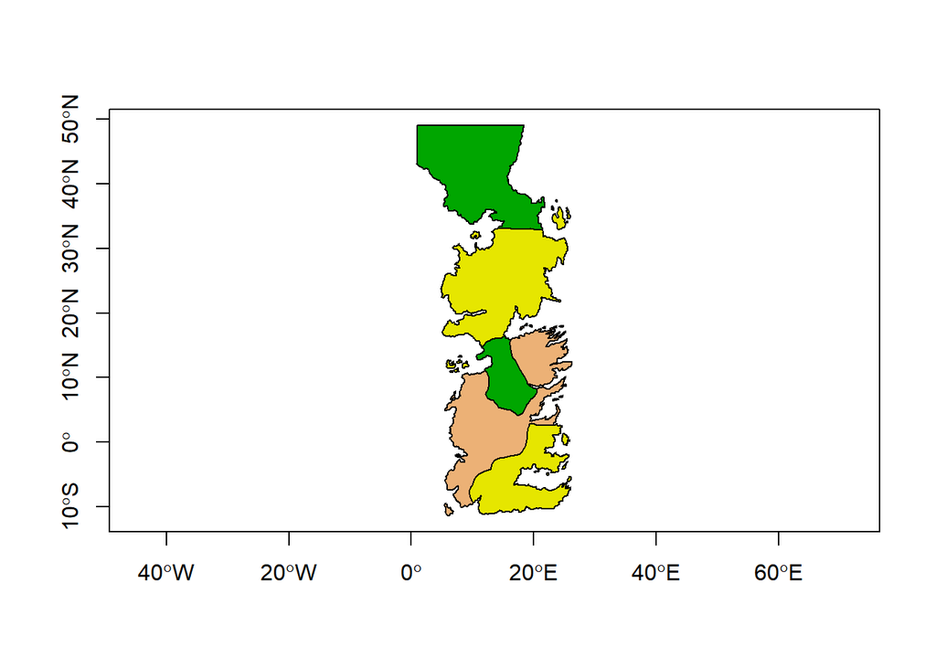

```r
plot(new_westeros, axes = T, col = terrain.colors(4))
```

## Exportando um shape

```
writeOGR(
  westeros_contorno, #nome do objeto a ser salvo
  dsn = "./data/meushape", #diretorio a serem salvos os resultados
  layer = "westeros_contorno", #nome do arquivo
  driver = "ESRI Shapefile" #formato pretendido para exportação
)
```

Com a função `ogrDrivers()` é possível ver todos os drivers disponíveis.

Veja que uma possibilidade é salvar em KML com o driver `KML`.

#criando raster a partir de um shape:

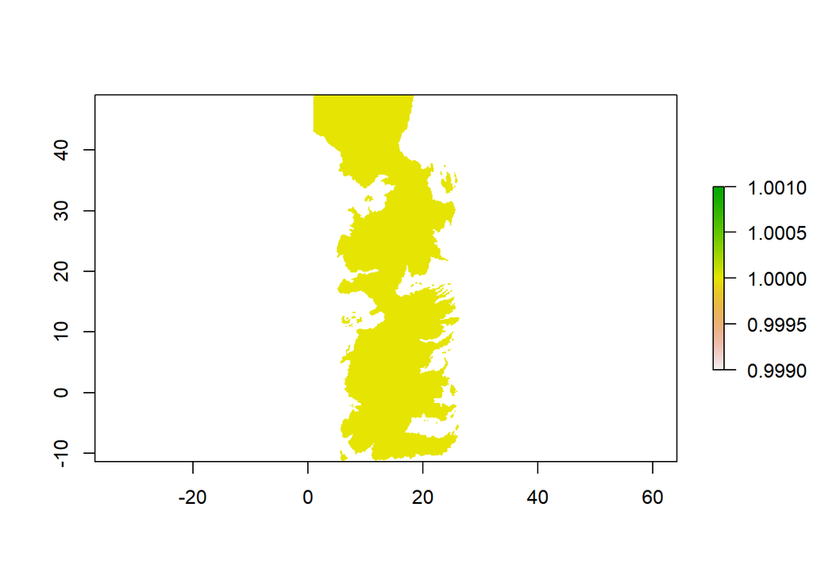

```r
westeros_raster <- raster(westeros_contorno, res = 0.08)
westeros_raster <- rasterize(westeros_contorno, westeros_raster) #deixando com o mesmo extent
plot(westeros_raster)
```

# Manipulação de raster

## Importando raster

Podemos importar um único raster com a função `raster`do pacote homônimo e múltiplos rasters com a função `stack`.

Um raster:

```r
var1 <- raster("./data/vars/var_1.tif")
var1
```

```
## class      : RasterLayer
## dimensions : 363, 153, 55539  (nrow, ncol, ncell)
## resolution : 0.1666667, 0.1666667  (x, y)
## extent     : 0.8333333, 26.33333, -11.33333, 49.16667  (xmin, xmax, ymin, ymax)
## crs        : +proj=longlat +datum=WGS84 +no_defs +ellps=WGS84 +towgs84=0,0,0
## source     : C:/Users/Diogo/Documents/GitHub/analise_de_dados_ENBT_2019/aula08/data/vars/var_1.tif
## names      : var_1
## values     : -29, 300  (min, max)
```

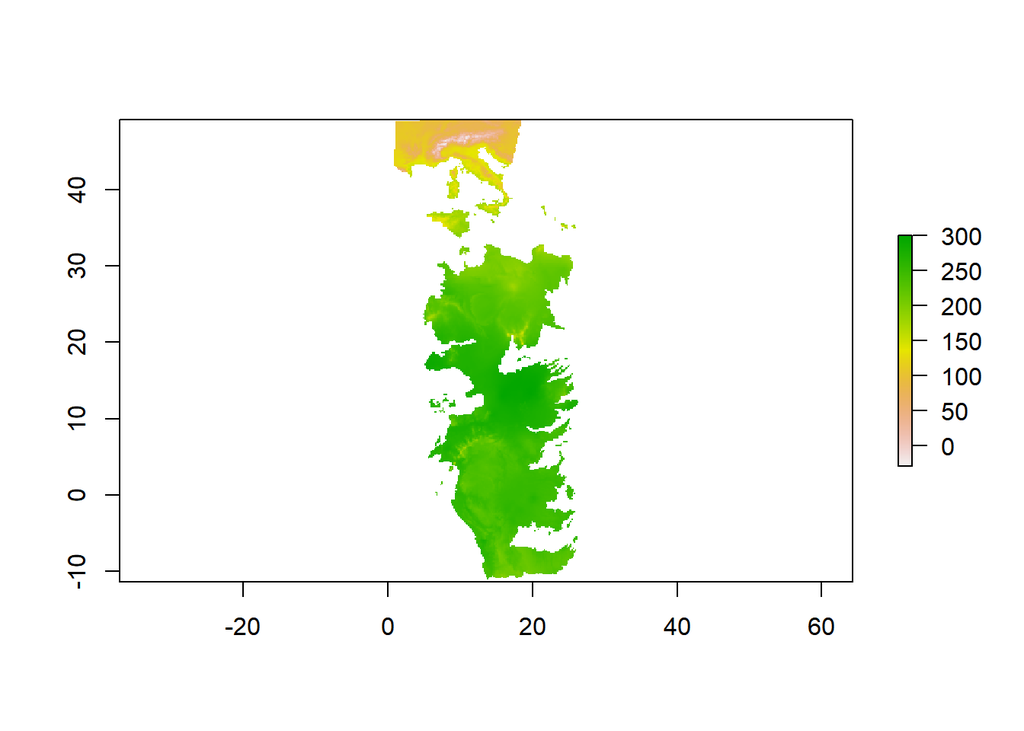

```r
plot(var1)
```

Múltiplos rasters:

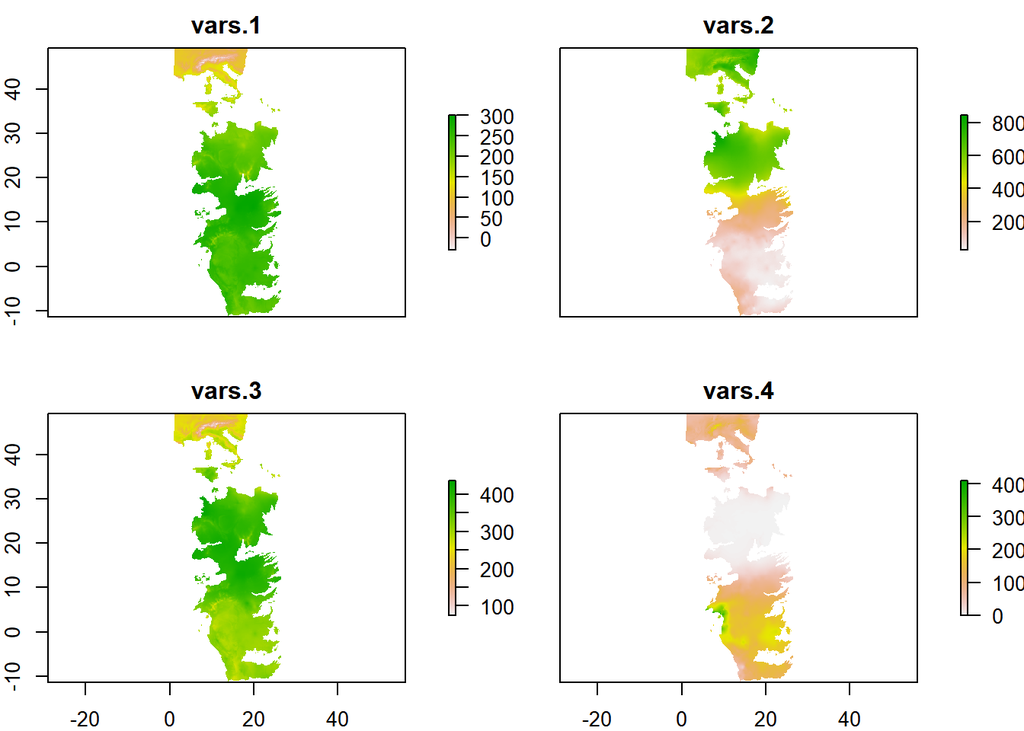

```r
lista <- list.files("./data", pattern = "tif$", full.names = T)
vars <- stack(lista)
plot(vars)
```

Um raster multi-banda:

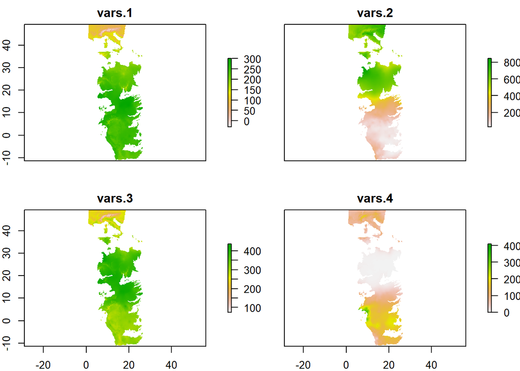

```r
vars <- stack("./data/vars.tif")
plot(vars)
```

## Salvando raster no arquivo

```
writeRaster(var1, "output.tif")
```

Note que por padrão o arquivo já é salvo no formato com base na extensão que você colocou no nome do arquivo. Caso não funcionar especifique o formato com o argumento `format = "GTiff"` para arquivos *Geotiff*.

veja os formatos suportados pelo pacote `raster` com `writeFormats()`.

Importante: Caso já exista um arquivo com o nome especificado, pode usar o argumento `overwrite = TRUE`.

## Álgebra de raster

É possível utilizar + operadores simples como: `+`, `-`, `*`, `/` + operadores lógicos como: `>`, `>=`, `<`, `==`, `!` + outras funções como: `abs, round, ceiling, floor, trunc, sqrt, log, log10, exp, cos, sin, max, min, range, prod, sum, any, all`

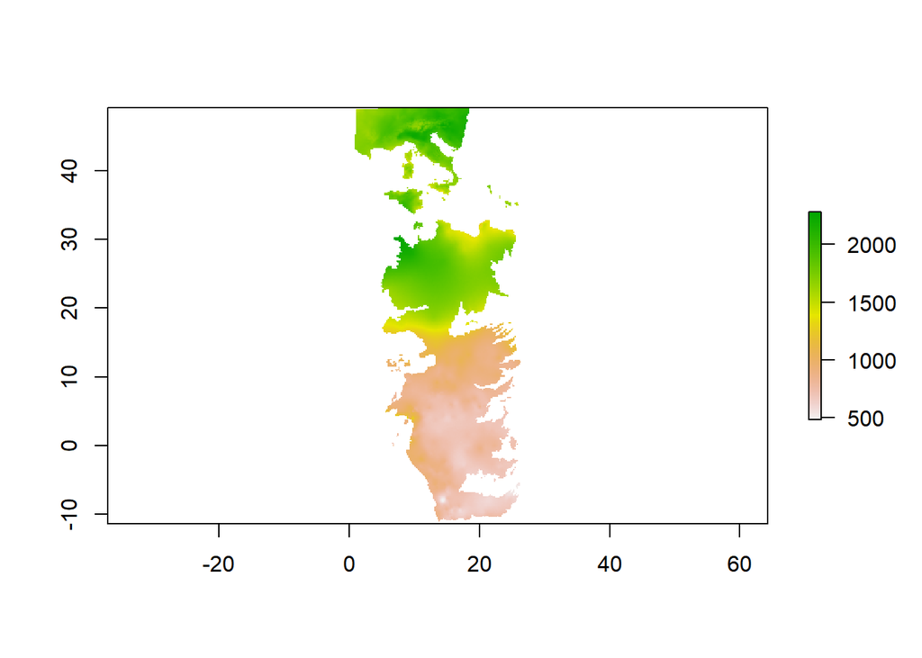

```r
media <- mean(vars)
plot(media)
```

## Modificando raster

Vamos utilizar o mesmo shape do início do tutorial para recortar um raster. Mas primeiro vamos selecionar parte deste shape.

```r
westeros <- readOGR("./data/GoTRelease/political.shp", encoding = "UTF-8")
stark <- westeros[westeros$ClaimedBy == "Stark",]
stark
```

```
## class       : SpatialPolygonsDataFrame
## features    : 1
## extent      : 4.867848, 26.00928, 14.80785, 37.58262  (xmin, xmax, ymin, ymax)
## crs         : +proj=longlat +datum=WGS84 +no_defs +ellps=WGS84 +towgs84=0,0,0
## variables   : 3
## names       : id,      name, ClaimedBy
## value       :  5, The North,     Stark
```

[figure not shown]

```r
plot(westeros, axes = T, las = 1)
plot(stark, add = T, col = "tomato")
```

Agora vamos recortar com `crop`. Esta função recorta um raster a partir de um extent, ou seja, recorta apenas um quadrilátero.

[figure not shown]

```r
plot(var1)
plot(westeros, add = T)
```

```r
var1_croped <- crop(var1, stark)
var1_croped
```

```
## class      : RasterLayer
## dimensions : 136, 127, 17272  (nrow, ncol, ncell)
## resolution : 0.1666667, 0.1666667  (x, y)
## extent     : 4.833333, 26, 14.83333, 37.5  (xmin, xmax, ymin, ymax)
## crs        : +proj=longlat +datum=WGS84 +no_defs +ellps=WGS84 +towgs84=0,0,0
## source     : memory
## names      : var_1
## values     : 117, 297  (min, max)
```

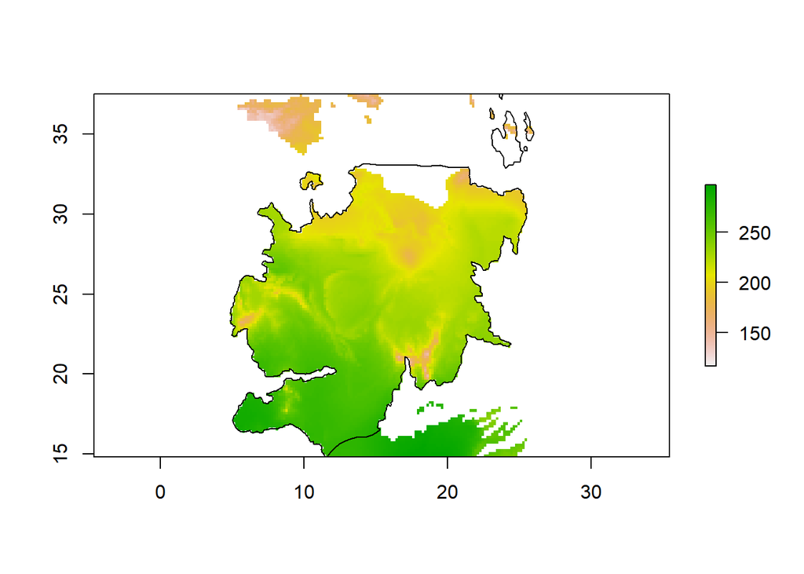

```r
plot(var1_croped)
plot(stark, add = T)
```

Com a função `mask` podemos recortar por uma mascara.

```r
var1_masked = mask(var1, stark)
var1_masked
```

```
## class      : RasterLayer
## dimensions : 363, 153, 55539  (nrow, ncol, ncell)
## resolution : 0.1666667, 0.1666667  (x, y)
## extent     : 0.8333333, 26.33333, -11.33333, 49.16667  (xmin, xmax, ymin, ymax)
## crs        : +proj=longlat +datum=WGS84 +no_defs +ellps=WGS84 +towgs84=0,0,0
## source     : memory
## names      : var_1
## values     : 117, 290  (min, max)
```

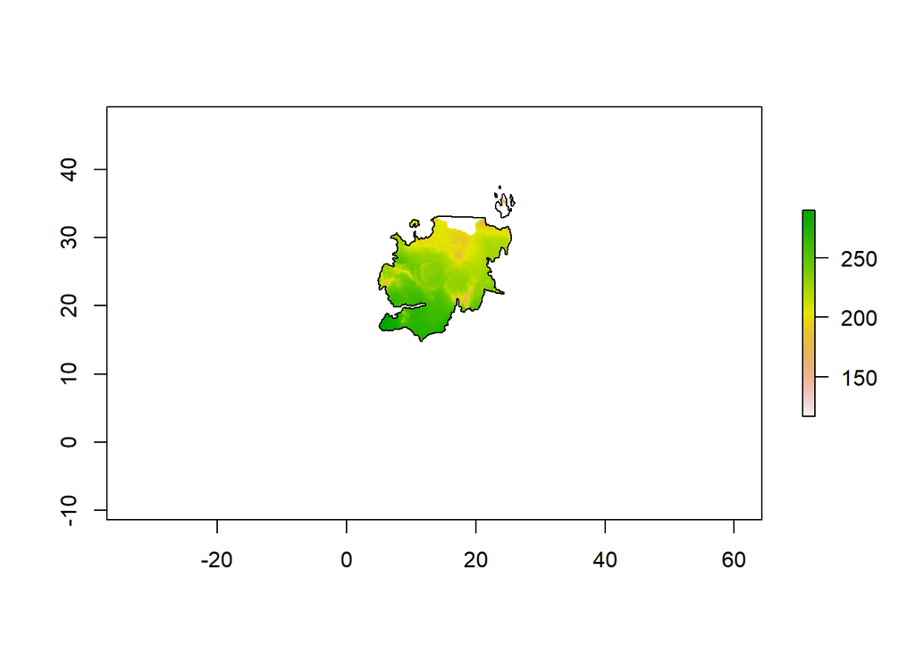

```r
plot(var1_masked)
plot(stark, add = T)
```

Mas, muitas vezes usar o `mask` direto pode ser uma operação muito lenta. Então, podemos combinar as funções `crop` e `mask` para otimizar o processamento.

```r
var1.masked2 = mask(crop(var1,stark), stark)
var1.masked2
```

```
## class      : RasterLayer
## dimensions : 136, 127, 17272  (nrow, ncol, ncell)
## resolution : 0.1666667, 0.1666667  (x, y)
## extent     : 4.833333, 26, 14.83333, 37.5  (xmin, xmax, ymin, ymax)
## crs        : +proj=longlat +datum=WGS84 +no_defs +ellps=WGS84 +towgs84=0,0,0
## source     : memory
## names      : var_1
## values     : 117, 290  (min, max)
```

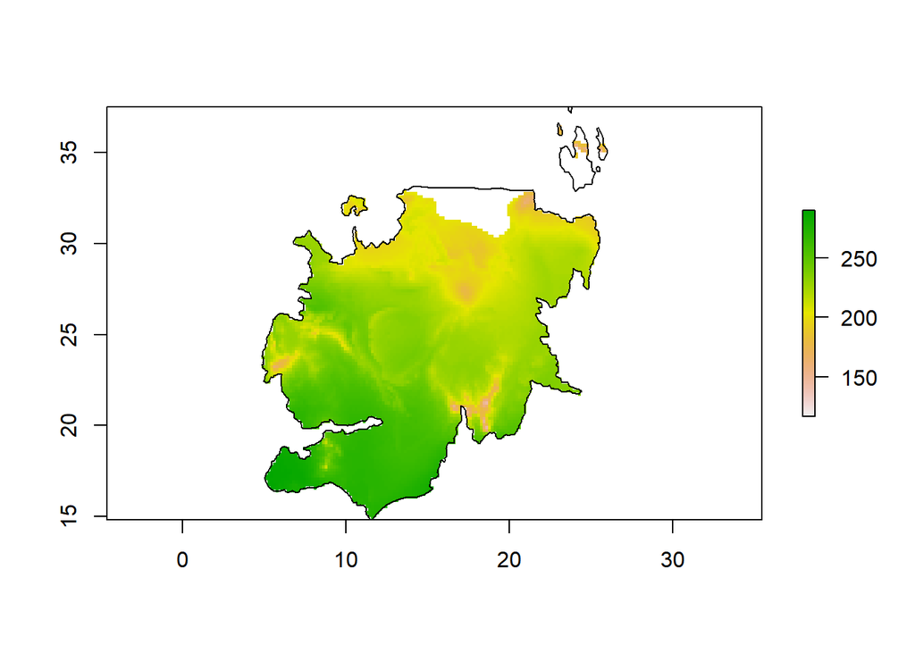

```r
plot(var1.masked2)
plot(stark, add = T)
```

Teste usar o argumento `inverse = TRUE` em `mask` e veja o que acontece.

## Alterando a resolução do raster

Com a Função `aggregate` é possível ‘piorar’ a resolução de um raster. Muda a resolução unindo as células vizinhas.

```r
var1.aggregated = aggregate(var1, fact = 5, fun = "mean")
var1.aggregated
```

```
## class      : RasterLayer
## dimensions : 73, 31, 2263  (nrow, ncol, ncell)
## resolution : 0.8333333, 0.8333333  (x, y)
## extent     : 0.8333333, 26.66667, -11.66667, 49.16667  (xmin, xmax, ymin, ymax)
## crs        : +proj=longlat +datum=WGS84 +no_defs +ellps=WGS84 +towgs84=0,0,0
## source     : memory
## names      : var_1
## values     : 10.12, 298.92  (min, max)
```

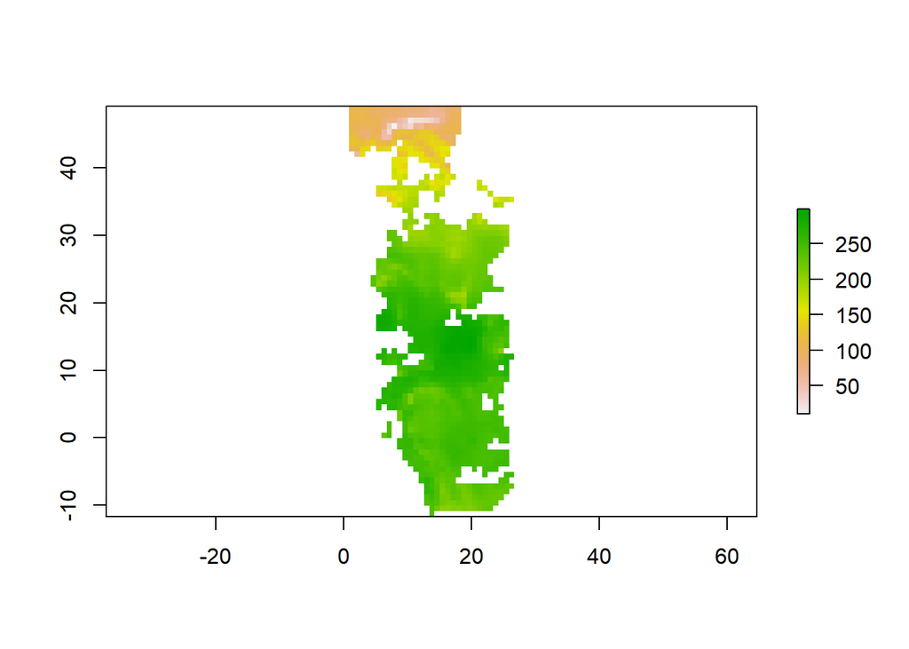

```r
plot(var1.aggregated)
```